# Example 1: Dynamic + Model Approach with Simulated Data

David D. Hofmann, Gabriele Cozzi, John Fieberg

2024-01-30

## Purpose

This example analysis serves to illustrate the application of the *dynamic + model* approach with simulated data. We’re first going to simulate a trajectory with known movement kernel and habitat-selection parameters (we call this the truth). We will then introduce data-missingness by randomly removing some of the simulated data-points. Finally, we will apply the *dynamic + model* approach and try to obtain the true simulation parameters.

## Disclaimer

In this script, we’ll utilize a set of custom functions that are stored in the `Functions.R` file. They are used to simulate covariates and movement, compute step-metrics, generate random-steps, and fit step distributions dynamically. Most of the functions can be replaced by much more generalized functions from the `amt` R-package. However, `amt`’s `random_steps()` function doesn’t cope well with sampling random steps from distributions fit to different step-durations. We’ll therefore use of our custom code. If you’d like to apply it to your own data, inspect the functions closels and verify that they suit your purposes.

## Preamble

Let’s start by preparing our R-Session and loading all necessary packages. We also load the custom functions stored in the `Functions.R` file.

```r
# Set notation standards
options(scipen = 999)

# Clear R's brain
rm(list = ls())

# Load required packages
library(tidyverse)     # For data wrangling
library(sf)            # For plotting spatial features
library(lubridate)     # To handle dates and times
library(raster)        # For spatial data manipulation
library(amt)           # To fit step-length and turning-angle distributions
library(survival)      # To fit conditional logistic regression model
library(ggh4x)         # For nested ggplot facets

# Load custom functions
source("02_R-Scripts/Functions.R")
```

## Simulation

We start by simulating a set of raster layers that represent the landscape on which we want to simulate movement. For this, we’ll use the functions `simDistance()`, `simElevation()`, and `simForest()`, which allow simulating spatially auto-correlated layers. You may also use functions from other packages, such as the `NLMR` or `gstat` packages, to generate such layers.

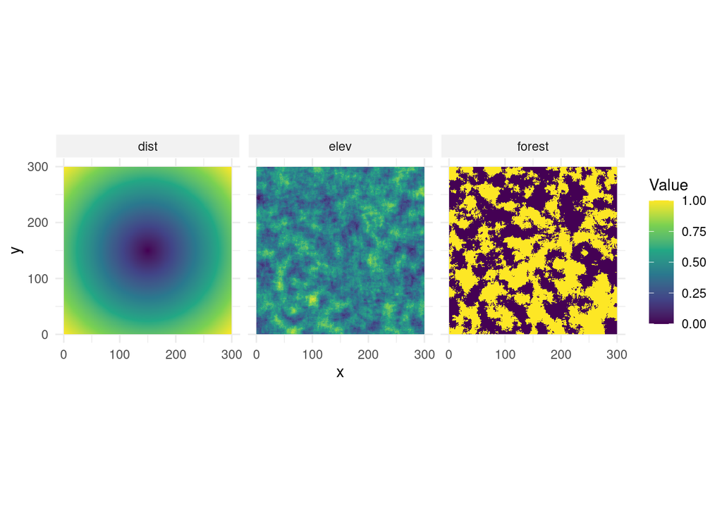

```r
# Set a seed for reproducability
seed <- 123456
set.seed(seed)

# Simulate landscape covariates (n x n)
n      <- 300
dist   <- simDistance(n, x = n / 2, y = n / 2)
elev   <- simElevation(n, autocorr_range = 10, seed = seed)
forest <- simForest(n, autocorr_range = 10, prop = 0.5, seed = seed + 1)
cov <- stack(dist, elev, forest)
names(cov) <- c("dist", "elev", "forest")

# Visualize the simulated covariates
cov %>%
  as.data.frame(xy = T) %>%
  pivot_longer(dist:forest, names_to = "Covariate", values_to = "Value") %>%
  ggplot(aes(x = x, y = y, fill = Value)) +
    geom_raster() +
    scale_fill_viridis_c() +
    scale_color_datetime(low = "red", high = "green", name = "Timestamp") +
    facet_wrap(~ Covariate) +
    coord_equal() +
    theme_minimal() +
    theme(strip.background = element_rect(fill = "gray95", color = "white"))
```

On this landscape, we now simulate a trajectory using the `move()` function. The function requires quite a few inputs, such as the starting location (`xy`), the covariate layers (`covars`), as well as a model formula (`formula`) and associated betas (`prefs`) that determine the habitat-selection function. Furthermore, we need to provide the step-length and turning-angle distributions from which random steps are sampled (`sl_dist` and `ta_dist`). The `move` function assumes a gamma distribution (with shape and scale parameters) for step-lengths and a von Mises distribution (with a concentration parameter kappa) for turning-angles. Finally, there are some simulation parameters that we need to define, including the extent on which simulated animals are allowed to move (`ext`), the number of steps simulated (`n_steps`), the number of random-steps proposed at each relocation (`n_rsteps`), whether the simulation should stop if one of the random steps leaves the study area (`stop`) and if a simulation-progressbar should be printed (`messages`).

```r
# Simulate a trajectory across this landscape
sim <- move(
    xy       = cbind(n / 2, n / 2)
  , covars   = cov
  , formula  = ~ dist + elev + forest
  , prefs    = c(-20, 1, -1)
  , sl_dist  = list(name = "gamma", params = list(shape = 3, scale = 1))
  , ta_dist  = list(name = "vonmises", params = list(kappa = 0.5, mu = 0))
  , ext      = as(extent(c(0, n, 0, n)), "SpatialPolygons")
  , n_steps  = 1000
  , n_rsteps = 25
  , stop     = F
  , messages = F
)

# Give the individual a random name
sim$id <- "Hermes"

# Add timestamps
sim$timestamp <- ymd_hms("2023-01-01 09:00:00") + hours(1) * sim$step_number

# Check it
head(sim, n = 10)
```

```
##           x        y    absta          ta       sl step_number     id
## 2  150.0000 150.0000 3.655327  2.08840735 2.589746           1 Hermes
## 3  148.7273 147.7446 3.683735  0.02840735 2.864172           2 Hermes
## 4  147.2495 145.2911 3.012142 -0.67159265 1.437651           3 Hermes
## 5  147.4351 143.8655 5.170549  2.15840735 4.098581           4 Hermes
## 6  143.7592 145.6783 5.118957 -0.05159265 1.268535           5 Hermes
## 7  142.5941 146.1799 6.007364  0.88840735 1.151278           6 Hermes
## 8  142.2805 147.2877 5.825771 -0.18159265 5.090600           7 Hermes
## 9  140.0324 151.8550 1.120993  1.57840735 2.468289           8 Hermes
## 10 142.2551 152.9281 1.619401  0.49840735 3.811656           9 Hermes
## 11 146.0623 152.7429 3.567808  1.94840735 2.853808          10 Hermes
##              timestamp
## 2  2023-01-01 10:00:00
## 3  2023-01-01 11:00:00
## 4  2023-01-01 12:00:00
## 5  2023-01-01 13:00:00
## 6  2023-01-01 14:00:00
## 7  2023-01-01 15:00:00
## 8  2023-01-01 16:00:00
## 9  2023-01-01 17:00:00
## 10 2023-01-01 18:00:00
## 11 2023-01-01 19:00:00
```

The `sim` data-frame represents the full “TRUE” movement trajectory of the simulated animal. Note that we simulated that fixes were collected exactly on the hour. This is usually not the case in real applications, but simplifies the subsequent code a bit. In any case, it’s straight forward to round timestamps of real data to the nearest hour or minute to avoid issues with slight deviations from the anticipated schedule. To mimic what real data would look like, we should also remove the step-metrics (`absta`, `ta`, `sl`), as they are usually not observed in reality and later have to be inferred from observed coordinates.

```r
# Remove columns that are not observed in reality
sim[, c("absta", "ta", "sl", "step_number")] <- NULL
head(sim, n = 10)
```

```
##           x        y     id           timestamp
## 2  150.0000 150.0000 Hermes 2023-01-01 10:00:00
## 3  148.7273 147.7446 Hermes 2023-01-01 11:00:00
## 4  147.2495 145.2911 Hermes 2023-01-01 12:00:00
## 5  147.4351 143.8655 Hermes 2023-01-01 13:00:00
## 6  143.7592 145.6783 Hermes 2023-01-01 14:00:00
## 7  142.5941 146.1799 Hermes 2023-01-01 15:00:00
## 8  142.2805 147.2877 Hermes 2023-01-01 16:00:00
## 9  140.0324 151.8550 Hermes 2023-01-01 17:00:00
## 10 142.2551 152.9281 Hermes 2023-01-01 18:00:00
## 11 146.0623 152.7429 Hermes 2023-01-01 19:00:00
```

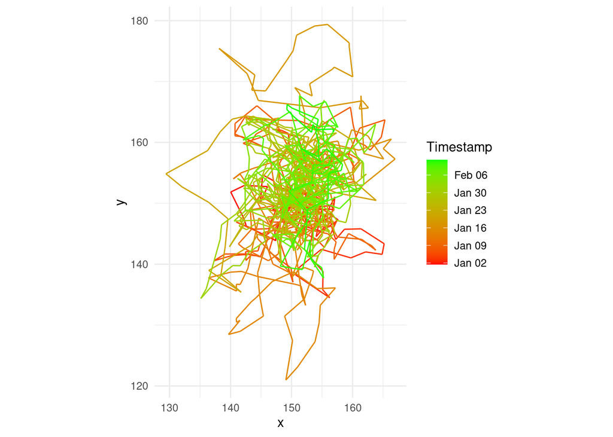

```r
# Visualize track
ggplot(sim, aes(x = x, y = y, col = timestamp)) +
  geom_path() +
  scale_color_datetime(low = "red", high = "green", name = "Timestamp") +
  coord_equal() +
  theme_minimal()
```

For later, we should keep track of the true simulation parameters. This will allow us to compare our model estimates from the iSSF model to the true parameters.

```r
# Keep track of true simulation parameters
truth <- data.frame(
    Term  = c("dist", "elev", "forest", "shape", "scale", "kappa")
  , Truth = c(-20, 1, -1, 3, 1, 0.5)
)
```

Now we rarify the full trajectory and create an “incomplete” dataset where some locations are missing.

```r
# Rarify track by randomly removing 25% of the fixes. You'll see that the number
# of fixes drops from 1000 to 750. We can then give each step an id (unique
# across individuals if there are many) and number (not unique across
# individuals if there are many)
sim_rarified <- sim %>%
  rarifyData(missingness = 0.25) %>%
  mutate(
      step_id     = 1:n()
    , step_number = 1:n()
  )

# Compare number of fixes
cbind(Original = nrow(sim), Rarified = nrow(sim_rarified))
```

```
##      Original Rarified
## [1,]     1000      750
```

The rarified trajectory is our point of departure and represents what we would observe in reality. Let’s again visualize everything.

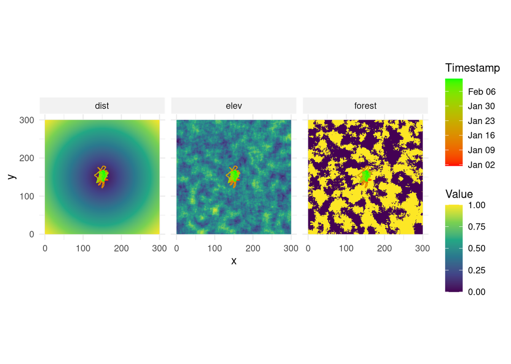

```r
# Visualize covariates and the rarified track
cov_df <- cov %>%
  as.data.frame(xy = T) %>%
  pivot_longer(dist:forest, names_to = "Covariate", values_to = "Value")
ggplot() +
  geom_raster(data = cov_df, aes(x = x, y = y, fill = Value)) +
  geom_path(data = sim_rarified, aes(x = x, y = y, col = timestamp)) +
  scale_fill_viridis_c() +
  scale_color_datetime(low = "red", high = "green", name = "Timestamp") +
  facet_wrap(~ Covariate) +
  coord_equal() +
  theme_minimal() +
  theme(strip.background = element_rect(fill = "gray95", color = "white"))
```

## Fitting Tentative Distributions

Because the dataset is incomplete, the time between consecutive datapoints is not always equal. Let’s figure out the regular (i.e. most frequent) step-duration.

```r
# Assess the regular step-duration of our data
samp <- sim_rarified %>%
  computeDurations() %>%
  count(duration)
samp
```

```
## # A tibble: 8 × 2
##   duration     n
##   <drtn>   <int>
## 1  1 hours   555
## 2  2 hours   157
## 3  3 hours    26
## 4  4 hours     6
## 5  5 hours     3
## 6  6 hours     1
## 7  7 hours     1
## 8 NA hours     1
```

```r
# Fit step-length and turning angle distributions to different durations
dists <- fitDists(sim_rarified
  , durations = 1:3 # Return fitted distributions for durations 1-3
  , regular   = 1   # The regular step-duration is 1
  , dynamic   = T   # Fit distributions dynamically
  , resample  = T   # Resample track to the different durations
  , rarify    = F   # Don't increase missingness
)

# Show the fitted values
dists
```

```
## $static
## $static$sl
## $static$sl$shape
## [1] 3.104669
##
## $static$sl$scale
## [1] 0.9760993
##
##
## $static$ta
## $static$ta$kappa
## [1] 0.336097
##
## $static$ta$mu
## [1] 0
##
##
##
## $dynamic
## $dynamic$sl
## # A tibble: 3 × 4
##   duration shape scale nsteps_sl
##      <int> <dbl> <dbl>     <int>
## 1        1  3.10 0.976       555
## 2        2  2.89 1.54        286
## 3        3  3.14 1.83        190
##
## $dynamic$ta
## # A tibble: 3 × 4
##   duration  kappa    mu nsteps_ta
##      <int>  <dbl> <dbl>     <int>
## 1        1 0.336      0       419
## 2        2 0.0807     0       216
## 3        3 0.154      0       142
```

You can see that we now have different gamma and von Mises parameters for steps from different durations. We can later use the so fitted distributions to generate random steps matching different step-durations.

## Generating Random Steps

Before generating random steps, we need to split our data into bursts within which the step-duration does not exceed 3.

```r
# Compute bursts within which the step duration does not exceed our forgiveness
sim_rarified_bursted <- computeBursts(sim_rarified, max_duration = 3)
head(sim_rarified_bursted)
```

```
## # A tibble: 6 × 9
##   id         x     y timestamp           step_id step_number duration irregular
##   <chr>  <dbl> <dbl> <dttm>                <int>       <int> <drtn>   <lgl>
## 1 Hermes  150   150  2023-01-01 10:00:00       1           1 2 hours  FALSE
## 2 Hermes  147.  145. 2023-01-01 12:00:00       2           2 1 hours  FALSE
## 3 Hermes  147.  144. 2023-01-01 13:00:00       3           3 1 hours  FALSE
## 4 Hermes  144.  146. 2023-01-01 14:00:00       4           4 1 hours  FALSE
## 5 Hermes  143.  146. 2023-01-01 15:00:00       5           5 2 hours  FALSE
## 6 Hermes  140.  152. 2023-01-01 17:00:00       6           6 2 hours  FALSE
## # ℹ 1 more variable: burst <dbl>
```

In addition, we need to compute step-metrics (step-lengths and turning-angles) per burst.

```r
# Compute step metrics within bursts
sim_rarified_metrics <- computeMetrics(sim_rarified_bursted)
head(sim_rarified_metrics)
```

```
## # A tibble: 6 × 12
##   burst step_number step_id id         x     y timestamp           duration
##   <dbl>       <int>   <int> <chr>  <dbl> <dbl> <dttm>              <drtn>
## 1     1           1       1 Hermes  150   150  2023-01-01 10:00:00 2 hours
## 2     1           2       2 Hermes  147.  145. 2023-01-01 12:00:00 1 hours
## 3     1           3       3 Hermes  147.  144. 2023-01-01 13:00:00 1 hours
## 4     1           4       4 Hermes  144.  146. 2023-01-01 14:00:00 1 hours
## 5     1           5       5 Hermes  143.  146. 2023-01-01 15:00:00 2 hours
## 6     1           6       6 Hermes  140.  152. 2023-01-01 17:00:00 2 hours
## # ℹ 4 more variables: irregular <lgl>, sl <dbl>, absta <dbl>, relta <dbl>
```

Finally, we can use the `computeSSF()` function to generate 25 random steps for each valid step (a valid step has a step-length and a turning-angle associated). Note that we cna use the dynamically fitted distributions `dists` to match sampled random steps with the step-durations of observed steps by picking the `dynamic+model` approach. The function `computeSSF()` will also automatically drop any invalid steps or steps with a duration that occurs less than 5 times in the dataset. This is to prevent issues when including the step-duration in the iSSF model.

```r
# Generate random steps
sim_rarified_ssf <- computeSSF(sim_rarified_metrics
  , n_rsteps = 25
  , dists    = dists
  , approach = "dynamic+model"
)
head(sim_rarified_ssf)
```

```
## # A tibble: 6 × 15
##   id     step_number step_id     x     y  x_to  y_to burst timestamp
##   <chr>        <int>   <int> <dbl> <dbl> <dbl> <dbl> <dbl> <dttm>
## 1 Hermes           2       2  147.  145.  147.  144.     1 2023-01-01 12:00:00
## 2 Hermes           2       2  147.  145.  144.  146.     1 2023-01-01 12:00:00
## 3 Hermes           2       2  147.  145.  145.  146.     1 2023-01-01 12:00:00
## 4 Hermes           2       2  147.  145.  150.  147.     1 2023-01-01 12:00:00
## 5 Hermes           2       2  147.  145.  149.  146.     1 2023-01-01 12:00:00
## 6 Hermes           2       2  147.  145.  150.  143.     1 2023-01-01 12:00:00
## # ℹ 6 more variables: duration <drtn>, irregular <lgl>, sl <dbl>, absta <dbl>,
## #   relta <dbl>, case <dbl>
```

Let’s visualize some of the observed and random steps to ensure everything is working as expected.

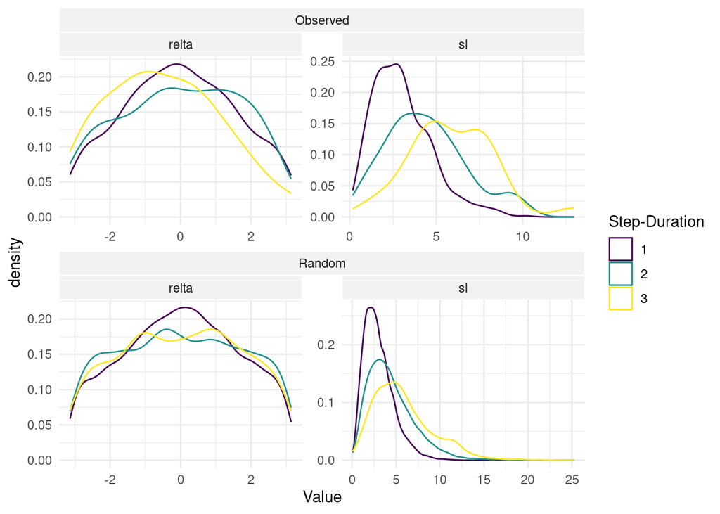

```r
# Verify that steps of different durations follow different sl- and
# ta-distributions
sim_rarified_ssf %>%
  dplyr::select(case, duration, sl, relta) %>%
  pivot_longer(sl:relta, names_to = "Metric", values_to = "Value") %>%
  mutate(Type = ifelse(case == 1, "Observed", "Random")) %>%
  ggplot(aes(x = Value, col = as.factor(duration))) +
    geom_density() +
    facet_nested_wrap(~ Type + Metric, scale = "free") +
    scale_color_viridis_d(name = "Step-Duration") +
    theme_minimal() +
    theme(strip.background = element_rect(fill = "gray95", color = "white"))
```

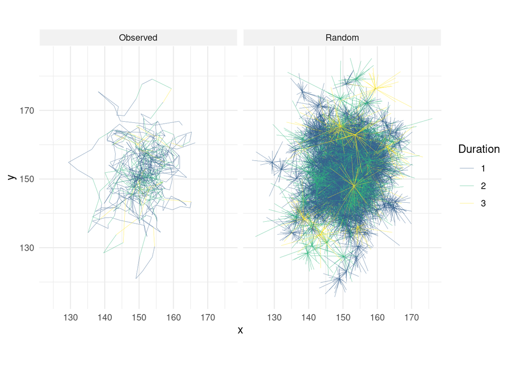

```r
# Visualize some observed and random steps
sim_rarified_ssf %>%
  mutate(Type = ifelse(case == 1, "Observed", "Random")) %>%
  subset(step_number %in% 1:1000) %>%
  ggplot(aes(x = x, y = y, xend = x_to, yend = y_to, col = as.factor(duration))) +
    geom_segment(linewidth = 0.1) +
    scale_color_viridis_d(begin = 0.3, name = "Duration") +
    theme_minimal() +
    coord_equal() +
    facet_wrap(~ Type) +
    theme(strip.background = element_rect(fill = "gray95", color = "white"))
```

## Computing Covariates

We still need to compute all covariates that we want include our iSSF model. This includes spatial covariates at the end-point of each step, as well as step-metrics. We can use the function `computeCovars` for this.

```r
# Compute covariates for all steps (the function will extract spatial covariates
# at the end of each step and also compute log_sl and cos_ta)
sim_rarified_covars <- computeCovars(sim_rarified_ssf
  , covars    = cov
  , extract   = "end"
)
head(sim_rarified_covars)
```

```
##       id step_number step_id        x        y     x_to     y_to burst
## 1 Hermes           2       2 147.2495 145.2911 147.4351 143.8655     1
## 2 Hermes           2       2 147.2495 145.2911 143.7084 145.6330     1
## 3 Hermes           2       2 147.2495 145.2911 145.0230 146.3564     1
## 4 Hermes           2       2 147.2495 145.2911 149.5115 146.5332     1
## 5 Hermes           2       2 147.2495 145.2911 148.6776 145.7997     1
## 6 Hermes           2       2 147.2495 145.2911 149.5883 143.4463     1
##             timestamp duration irregular       sl    absta      relta case
## 1 2023-01-01 12:00:00  1 hours     FALSE 1.437651 3.012142 -0.6581037    1
## 2 2023-01-01 12:00:00  1 hours     FALSE 3.557565 4.808653  1.1384073    0
## 3 2023-01-01 12:00:00  1 hours     FALSE 2.468193 5.158653  1.4884073    0
## 4 2023-01-01 12:00:00  1 hours     FALSE 2.580620 1.068653 -2.6015927    0
## 5 2023-01-01 12:00:00  1 hours     FALSE 1.515995 1.228653 -2.4415927    0
## 6 2023-01-01 12:00:00  1 hours     FALSE 2.978813 2.238653 -1.4315927    0
##         dist      elev forest    log_sl     cos_ta
## 1 0.02969415 0.6222209      1 0.3630105  0.7911535
## 2 0.03416221 0.6364946      1 1.2690764  0.4190411
## 3 0.02369885 0.6477892      1 0.9034864  0.0822958
## 4 0.01342282 0.6233806      0 0.9480296 -0.8577087
## 5 0.01915505 0.5903962      0 0.4160720 -0.7648422
## 6 0.02758236 0.6297780      1 1.0915249  0.1387545
```

## Running the Model

We are now ready to estimate parameters using conditional logistic regression. This can be achieved using the `clogit()` function from the `survival` package. Alternatively, one can use the wrapper `fit_clogit()` from the `amt` package. Importantly, we will include interactions among the step-descriptors $sl$, $log(sl)$, and $cos(ta)$ and the step-duration $duration$.

```r
# Ensure the step-duration enters as factor
sim_rarified_covars$duration <- as.factor(sim_rarified_covars$duration)

# Fit the model
mod <- clogit(data = sim_rarified_covars, formula = case ~
  + dist            # Habitat-selection
  + elev            # Habitat-selection
  + forest          # Habitat-selection
  + sl              # Movement Kernel
  + log_sl          # Movement Kernel
  + cos_ta          # Movement Kernel
  + sl:duration     # Movement x Step-Duration
  + log_sl:duration # Movement x Step-Duration
  + cos_ta:duration # Movement x Step-Duration
  + strata(step_id)
)
summary(mod)
```

```
## Call:
## coxph(formula = Surv(rep(1, 18876L), case) ~ +dist + elev + forest +
##     sl + log_sl + cos_ta + sl:duration + log_sl:duration + cos_ta:duration +
##     strata(step_id), data = sim_rarified_covars, method = "exact")
##
##   n= 18876, number of events= 726
##
##                              coef        exp(coef)         se(coef)      z
## dist             -20.673830108811   0.000000001051   3.967993416063 -5.210
## elev               1.107012264153   3.025306062811   0.655327767786  1.689
## forest            -1.034707161617   0.355330420076   0.106991756289 -9.671
## sl                 0.051939012502   1.053311501721   0.066257454846  0.784
## log_sl            -0.021092101426   0.979128781259   0.181544194280 -0.116
## cos_ta             0.148077841209   1.159603157762   0.065832263688  2.249
## sl:duration2      -0.018412123912   0.981756343708   0.106265485395 -0.173
## sl:duration3      -0.401657457323   0.669209939398   0.260309337248 -1.543
## log_sl:duration2   0.099681532714   1.104819013330   0.378939537630  0.263
## log_sl:duration3   2.425927229659  11.312714041685   1.430036513826  1.696
## cos_ta:duration2   0.098364777857   1.103365194901   0.139288950167  0.706
## cos_ta:duration3   0.066687911367   1.068961815279   0.317075313502  0.210
##                              Pr(>|z|)
## dist                      0.000000189 ***
## elev                           0.0912 .
## forest           < 0.0000000000000002 ***
## sl                             0.4331
## log_sl                         0.9075
## cos_ta                         0.0245 *
## sl:duration2                   0.8624
## sl:duration3                   0.1228
## log_sl:duration2               0.7925
## log_sl:duration3               0.0898 .
## cos_ta:duration2               0.4801
## cos_ta:duration3               0.8334
## ---
## Signif. codes:  0 '***' 0.001 '**' 0.01 '*' 0.05 '.' 0.1 ' ' 1
##
##                        exp(coef)     exp(-coef)          lower .95
## dist              0.000000001051 951766327.9673 0.0000000000004405
## elev              3.025306062811         0.3305 0.8374392470286933
## forest            0.355330420076         2.8143 0.2881116643408470
```

[output cut: 12 more lines]

```
## forest             0.438231849
## sl                 1.199375780
## log_sl             1.397560171
## cos_ta             1.319307143
## sl:duration2       1.209085635
## sl:duration3       1.114648901
## log_sl:duration2   2.321908272
## log_sl:duration3 186.558953434
## cos_ta:duration2   1.449713722
## cos_ta:duration3   1.990018840
##
## Concordance= 0.642  (se = 0.011 )
## Likelihood ratio test= 201.2  on 12 df,   p=<0.0000000000000002
## Wald test            = 194.4  on 12 df,   p=<0.0000000000000002
## Score (logrank) test = 205.9  on 12 df,   p=<0.0000000000000002
```

This looks good. Now we extract the model coefficients from the fitted model and use them to update our “tentative” distribution parameters for the gamma and von Mises distribution. Since the true data was simulated with $\Delta t = 1$, we will only update parameters for the case when $\Delta t = 1$.

```r
# Compute confidence intervals
ci <- confint(mod, level = 0.95)

# Put relevant results together
coefs <- summary(mod)$coefficients
coefs <- data.frame(
    Coefficient = rownames(coefs)
  , Estimate    = coefs[, "coef"]
  , SE          = coefs[, "se(coef)"]
  , Z           = coefs[, "z"]
  , LCI         = ci[, 1]
  , UCI         = ci[, 2]
)

# We can use this dataframe to update our tentative distribution parameters.
corrected <- correctDists(list(
    Dists = dists
  , Coefs = coefs
))
corrected$Dists$updated
```

```
## $sl
## $sl$shape
## [1] 3.083577
##
## $sl$scale
## [1] 1.028228
##
##
## $ta
## $ta$kappa
## [1] 0.4841748
##
## $ta$mu
## [1] 0
```

Finally, we put all results together into a `data.frame` and compare them to the truth.

```r
# Now put everything together into a dataframe
mov_estimates <- corrected$Dists
hab_estimates <- corrected$Coefs

# Compile the updated distribution parameters (for step duration of one)
mov_estimates <- tibble(
    shape = as.numeric(mov_estimates$updated$sl$shape)
  , scale = as.numeric(mov_estimates$updated$sl$scale)
  , kappa = as.numeric(mov_estimates$updated$ta$kappa)
  ) %>%
  pivot_longer(shape:kappa, names_to = "Term", values_to = "Estimate") %>%
  mutate(Kernel = "Movement")

# Compile the habitat selection coefficients
hab_estimates <- hab_estimates %>%
  dplyr::select(Term = Coefficient, Estimate) %>%
  subset(Term %in% c("forest", "dist", "elev")) %>%
  mutate(Kernel = "Habitat")

# Put them together
estimates <- rbind(hab_estimates, mov_estimates, make.row.names = F)
estimates
```

```
##     Term    Estimate   Kernel
## 1   dist -20.6738301  Habitat
## 2   elev   1.1070123  Habitat
## 3 forest  -1.0347072  Habitat
## 4  shape   3.0835772 Movement
## 5  scale   1.0282280 Movement
## 6  kappa   0.4841748 Movement
```

```r
# Compare to truth
comparison <- left_join(truth, estimates, by = "Term")
comparison
```

```
##     Term Truth    Estimate   Kernel
## 1   dist -20.0 -20.6738301  Habitat
## 2   elev   1.0   1.1070123  Habitat
## 3 forest  -1.0  -1.0347072  Habitat
## 4  shape   3.0   3.0835772 Movement
## 5  scale   1.0   1.0282280 Movement
## 6  kappa   0.5   0.4841748 Movement
```

Wonderful. It looks like we were able to approximate the true simulation parameters quite well.